# **[Universidade Federal Rural de Pernambuco](http://ufrpe.br/)** **[Departamento de Matemática](http://www.dm.ufrpe.br/)** **[Disciplina: Análise Combinatória](https://sites.google.com/site/ricardonunesmachadojr/disciplinas/analise-combinatoria)** **[Prof. Ricardo Machado](https://sites.google.com/site/ricardonunesmachadojr/)**

## [Índice de Aulas](https://sagectu.com.br/calculo1.github.io/combinatoria.html) Aula 7

## 1 - 1º Lema de Kaplansky 2 - 2º Lema de Kaplansky 3 - Parte extra, Kaplansky no SageMath 4 - Exercícios

# Referências:

### Observação: Nota de aula produzida usando o software [SageMath](http://www.sagemath.org/), usando o notebook [Jupyter](https://jupyter.org/). Use o SageMathCell com vários exemplos em: sagectu.com.br/sagecell.html Referência bibliográfica sobre o SageMath: [1] Silva, L., Santos M., Machado, R., [*Elementos de Computação Matemática com SageMath*](https://sagectu.com.br/), SBM, 2019.

[figure not shown]

```python
load ('/home/ricardo/sage-9.0-Debian_GNU_Linux_9-x86_64/SageMath/Sage_Sync/Combinatoria/codigos.sage')
```

## Observação Esta nota de aula foi baseada na referência [3].

## 1 - 1º Lema de Kaplansky

### Para podermos compreender os benefícios dos Lemas de Kaplansky, iniciaremos essa nota de aula com o exemplo a seguir:

### Exemplo 1 De quantos maneiras podemos formar um subconjunto com 4 elementos, do conjunto $$A=\{a,b,c,d,e,f,g,h\},$$ de modo que não possuam duas letras que ocupem posições consecutivas no alfabeto?

### Solução Esse problema será resolvido criando uma forma alternativa de representar os subconjuntos onde marcaremos com o sinal $(+)$ os elementos pertencente ao subconjunto e com o sinal $(-)$ os elementos que não pertencentes ao subconjunto. $$\{a,c,e,h\} \text{ será representado por } +-+-+--+$$$$\{b,d,f,h\} \text{ será representado por } -+-+-+-+$$$$\{b,e,g,h\} \text{ será representado por } -+--+-++$$ (O terceiro caso não é válido, pois 2 $(+)$ juntos significa que teremos letras consecutivas) Assim, compreendendo o problema observa-se que para soluciona-lo devemos calcular o número de formas distintas de permutar 8 símbolos, onde $4$ são $(-)$ e $4$ são $(+)$ de modo que não tenha 2 símbolos $(+)$ juntos. $$ \bigcirc-\bigcirc-\bigcirc-\bigcirc-\bigcirc$$ Veja que de acordo com a figura (de círculos e traços) podem-se colocar 4 símbolos $(+)$ em quaisquer dos cinco lugares, ou seja, é possível escolher 4 dos 5 lugares disponíveis (representados pelas circunferências) para por os símbolos $(+)$ o que pode ser realizado de $$C_5^4=5 \text{ modos distintos}.$$ Dessa forma 5 subconjuntos podem ser formados, os quais estão listados abaixo: $$ \{ a, c, e, g \}, \{ a, c, e, h \}, \{ a, c, f, h \}, \{ a, d, f, h \}, \{ b, d, f, h \} $$ $\blacksquare$

### Usando a função implementada no final desta nota de aula:

```python
kaplansky_bijecao(['A', 'B', 'C', 'D', 'E', 'F', 'G', 'H'], 4)
```

```
[[A, C, E, G], [A, C, E, H], [A, C, F, H], [A, D, F, H], [B, D, F, H]]
```

### Teorema 1 (Primeiro Lema de Kaplansky) O número de $p-$subconjuntos de $\{1,2,3,\cdots,n\}$ nos quais não há números consecutivos é $$K(n,p)=C_{n-p+1}^p$$

### Demonstração Deseja-se formar subconjuntos formados por $p$ elementos não consecutivos. De acordo com o exemplo anterior, os elementos desse subconjunto serão representados com o símbolo $(+)$. Assim teremos $(n-p)$ elementos que serão apresentados com o símbolo $(-)$, que retratam os números que não estarão no subconjunto. Entre os símbolos $(-)$ existirão $(n-p+1)$ espaços vazios disponíveis. Desta forma resta escolher entre os $(n-p+1)$ espaços vazios aqueles que serão ocupados pelos símbolos (+). Logo, $$K(n,p)=C_{n-p+1}^p$$ $\blacksquare$

### Definindo K(n,p) no SageMath

```python
K(n,p) = C(n-p+1, p)
```

### Exemplo 2 Um exame vestibular se constitui de 10 provas distintas, 3 das quais da área de Matemática. Determine de quantas formas é possível programar a sequência das 10 provas, de maneira que duas provas da área de Matemática não se sucedam.

### Solução São 3 provas de Matemática e 7 provas quaisquer $(Q_1, Q_2,\cdots, Q_7)$. Inicialmente, iremos dispor as provas que não sofrem restrições. $$\bigcirc \ Q_1\ \bigcirc \ Q_2 \ \bigcirc \ Q_3 \ \bigcirc \ Q_4 \ \bigcirc \ Q_5 \ \bigcirc \ Q_6 \ \bigcirc \ Q_7 \ \bigcirc$$ Temos 8 lugares $\bigcirc$ para colocar as 3 provas de Matemática e isso pode ser feito utilizando o 1º Lema de Kaplansky: $$K(10,3).$$ Devemos, agora, permutar a ordem das 7 provas quaisquer e as 3 de Matemática. Assim, temos $$7! \times 3!$$ possibilidades. Assim, o total de formas de programar a sequência dessas 10 provas é: $$ K(10, 3)\times 7! \times 3! = 1693440. $$ $\blacksquare$

```python
K(10, 3)*P(7)*P(3)
```

```
1693440
```

## 2 - 2º Lema de Kaplansky

### Teorema 2 (Segundo Lema de Kaplansky) O número de $p$-subconjuntos de $\{1,2,3,\cdots,n\}$, que não possuam números consecutivos, considerando $1$ e $n$ consecutivos, é: $$KC(n,p)=\frac{n}{n-p}\times C_{n-p}^p$$

### Demonstração O problema será dividido em dois casos: (1) O elemento $1$ pertencendo ao subconjunto composto por $p$ elementos. Neste caso, será feito a análise de quantos formas poderá serão escolhidos os outros $p-1$ elementos do conjunto $\{3,4,5,\cdots,n-1\}$, pois os elementos $1$ e $n$ não podem pertencer ao conjunto. Dessa forma, utilizando o primeiro lema de Kaplansky, o número de maneiras que isso pode ocorrer é: $$K(n-3,p-1)=C^{p-1}_{n-p-1}=\dfrac{(n-p-1)!}{(n-2p)!\cdot(p-1)!}$$ (2) O elemento $1$ não pertencendo ao subconjunto composto por $p$ elementos. Nesse caso a escolha de $p$ elementos será realizado entre os elementos do conjunto $\{2,3,4,...n\}$. No entanto pelo primeiro lema de Kaplansky a escolha será determinada por $$K(n-1,p)=C^p_{n-p}=\dfrac{(n-p)!}{(n-2p)!\cdot p!}$$ Portanto, através dos casos (1) e (2), a solução do problema será dado por: \begin{equation*} \begin{split} KC(n,p)=&~\dfrac{(n-p-1)!}{(n-2p)!\cdot(p-1)!}+\dfrac{(n-p)!}{(n-2p)!\cdot p!} \\ =&~ \dfrac{p\cdot (n-p-1)!+(n-p)\cdot(n-p-1)!}{{(n-2p)!\cdot p!}}\\ = &~ \dfrac{(n-p-1)!n}{{(n-2p)!\cdot p!}}\\ = &~ \dfrac{n-p}{n-p}\cdot\dfrac{(n-p-1)!n}{(n-2p)!\cdot p!}\\ = &~ \dfrac{n}{n-p}\cdot\dfrac{(n-p)!}{(n-2p)!\cdot p!} \end{split} \end{equation*} E finalmente, $$KC(n,p)=\dfrac{n}{n-p}\cdot C^p_{n-p}$$ $\blacksquare$

## Definindo KC(n,p) no SageMath

```python
KC(n,p) = (n/(n-p))*C(n-p, p)
```

### Exemplo Débora deseja correr 3 vezes por semana durante esse bimestre. De quantas formas ela poderá escolher os dias da corrida, se Débora não deseja correr em dias consecutivos?

### Solução Nesta questão observa-se que a disposição dos dias da semana geram um sistema cíclico, ou seja, o início de uma semana dá continuação ao fim da semana anterior a ela e assim sucessivamente, como pode ser verificado na figura abaixo:

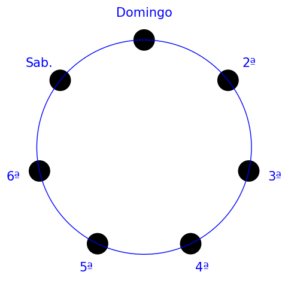

```python
permuta_circular_x(['Domingo', '2ª', '3ª', '4ª', '5ª', '6ª', 'Sab.'])
```

### Desta forma, Débora deve escolher 3 dias entre: domingo, segunda, terça, quarta, quinta, sexta e sábado de maneira que não apareçam dois dias consecutivos. O número de maneiras que Débora pode escolher os 3 dias é: $$ KC(7, 3) = 7.$$ $\blacksquare$

```python
KC(7, 3)
```

```
7
```

### Exemplo Dado um decágono, quantos são os triângulos cujos vértices são vértices não consecutivos do decágono?

### Solução O resultado esperado corresponde a escolha de $3$ elementos não consecutivos de um conjunto de $10$ elementos (vértices). Assim, tem-se: $$KC(10, 3) = 50.$$

```python
KC(10, 3)
```

```
50
```

# 3 - Parte extra, Kaplansky no SageMath

### Gerando os p-subconjutos segundo o 1º Lema de Kaplansky no SageMath

```python
def kaplansky(n, p):

    comb = Combinations(range(1, n+1), p)
    lcomb = comb.list()

    for c in comb:
        for i in range(len(c)-1):
            if c[i]+1 == c[i+1]:
                lcomb.remove(c)
                break

    return lcomb
```

```python
kaplansky(8, 4)
```

```
[[1, 3, 5, 7], [1, 3, 5, 8], [1, 3, 6, 8], [1, 4, 6, 8], [2, 4, 6, 8]]
```

```python
def kaplansky_bijecao(lista, p):

    k = kaplansky(len(lista), p)
    k2 = []

    for i in k:
        laux = []
        for j in i:
            laux.append(SR(lista[j-1]))
        k2.append(laux)

    return k2
```

```python
kaplansky_bijecao(['A', 'B', 'C', 'D', 'E', 'F', 'G', 'H'], 4)
```

```
[[A, C, E, G], [A, C, E, H], [A, C, F, H], [A, D, F, H], [B, D, F, H]]
```

### Exemplo Quais são todas as maneiras podemos formar subconjuntos com 4 elementos, do conjunto $$A=\{1,2,3,4,5,6,7,8\},$$ de modo que não possuam dois números consecutivos?

```python
kaplansky(8, 4)
```

```
[[1, 3, 5, 7], [1, 3, 5, 8], [1, 3, 6, 8], [1, 4, 6, 8], [2, 4, 6, 8]]
```

### Gerando os p-subconjutos segundo o 2º Lema de Kaplansky no SageMath

```python
def kaplansky_c(n, p):

    comb = Combinations(range(1, n+1), p)
    lcomb = comb.list()

    for c in comb:
        for i in range(len(c)):
            if i < len(c)-1:
                if c[i]+1 == c[i+1]:
                    lcomb.remove(c)
                    break
            else:
                if c[i] == n and c[0] == 1:
                    lcomb.remove(c)
                    break

    return lcomb
```

```python
def kaplansky_c_bijecao(lista, p):

    k = kaplansky_c(len(lista), p)
    k2 = []

    for i in k:
        laux = []
        for j in i:
            laux.append(SR(lista[j-1]))
        k2.append(laux)

    return k2
```

### Exemplo Débora deseja correr 3 vezes por semana durante esse bimestre. Quais são as formas que ela poderá escolher os dias da corrida, se Débora não deseja correr em dias consecutivos?

```python
kaplansky_c_bijecao(['Dom', 'Seg', 'Ter', 'Qua', 'Qui', 'Sex', 'Sab'], 3)
```

```
[[Dom, Ter, Qui],
 [Dom, Ter, Sex],
 [Dom, Qua, Sex],
 [Seg, Qua, Sex],
 [Seg, Qua, Sab],
 [Seg, Qui, Sab],
 [Ter, Qui, Sab]]
```

### 4 - Exercícios 8 pessoas devem se sentar em 25 cadeiras colocadas em torno de uma mesa circular. De quantos modos isso pode ser feito se não deve haver ocupação simultânea de duas cadeiras adjacentes? $$ $$ De quantos modos é possível formar uma roda de ciranda com 8 meninas e 12 meninos sem que haja duas meninas em posições adjacentes? $$ $$ Quantos são os anagramas de ARARAQUARA que não possuem duas letras A consecutivas?